# Prognostic Factors of Melanoma-Specific Mortality: A Retrospective Cohort

Competing Risk Analysis to Account for Non-Melanoma Deaths

Abderrezzaq KADOUCHE

## **Introduction**

Malignant cutaneous melanoma is one of the most aggressive forms of skin cancer. Evaluating its long-term survival outcomes is critical for developing prognostic profiles and public health strategies. While randomized clinical trials offer a controlled environment to study efficacy, they often apply strict exclusion criteria that mask the complexities of real-world populations. This study is contextualized within the field of Real-World Evidence (RWE), analyzing historical clinical data from patients who underwent definitive surgical treatment. In this non-randomized, real-world setting, patients are older, present multiple comorbidities, and face a dual threat: the progression of their primary cancer or death from unrelated medical events. Understanding the interplay between tumor characteristics at the time of surgery and long-term mortality—while mathematically separating cancer virulence from background population mortality—provides the necessary epidemiological context to optimize patient care and survival tracking.

## **Objective**

**• Primary Objective**: To estimate the true absolute risk of melanoma-specific mortality over time by implementing a robust competing risks framework.

**• Secondary Objective**: To quantify the impact of key clinical factors —specifically tumour thickness and the presence of histological ulceration— on disease-specific mortality.

## **Study Design**

This is a retrospective, observational cohort study based on historical, longitudinal medical records. Because the investigator did not assign the intervention (surgical removal of the tumor was standard clinical practice for all diagnosed individuals), the study relies on the passive observation of patient trajectories over a multi-year follow-up period.

## **Data Source**

The clinical observations analyzed in this research originate from the seminal study conducted by P. K. Andersen, O. Borgan, R. D. Gill, and N. Keiding (1993), published in their foundational work Statistical Models based on Counting Processes. This historical dataset serves as the core empirical basis for our survival and competing risks assessments.

**• Study Population:** The baseline sample comprises 205 patients diagnosed with malignant cutaneous melanoma who underwent complete surgical resection at the Department of Plastic Surgery, University Hospital of Odense, Denmark. The recruitment and surgical interventions took place between 1962 and 1977.

**• Follow-up Period:** Patients were followed prospectively from the exact date of their surgical procedure until an administrative censoring date at the end of 1977.

## **Variable Specifications**

• `time` : Survival time measured in days from the exact date of the surgical operation to the date of death or last follow-up.

• `status` : (1 = Melanoma Death, 2 = Alive, 3 = Other Death) : Multi-state categorical endpoint representing the mutually exclusive final events, where death from other causes acts as the competing risk to the primary event of interest.

• `thickness` : Tumour thickness measured in millimeters (mm), representing the Breslow depth of penetration of the primary melanoma.

• `ulcer` : (1 = Presence, 0 = Absence): Histological binary indicator showing the presence or absence of ulceration on the surface of the primary tumour.

• `age` : Patient’s age in years at the time of the surgical procedure.

• `sex` : 1 = Male, 0 = Female.

• `year` : Calendar year in which the surgical operation was performed, ranging from 1962 to 1977.

# **CDISC alignment**

| SDTM Domain | Source Variable | SDTM Variable | ADaM Variable |
| --- | --- | --- | --- |
| DM (Demographics) | sex | DM.SEX | ADSL.SEX |
|  | age | DM.AGE | ADSL.AGE |
| MH (Medical History) | ulcer | MH.MHORRES | ADSL.ULCERFL |
| VS (Vital Signs) | thickness | VS.VSORRES | ADSL.THICK |
| DS (Disposition) | year | DS.DSSTDTC | ADSL.TRTYEAR |
|  | time | DS.DSSTDY | ADTTE.AVAL |
|  | status | DS.DSDECOD | ADTTE.CNSR / ADTTE.EVNTDESC |

## **Descriptive analysis of continuous variables**

```r
library(prettyR)

vars_quanti <- c("age", "thickness")

describe(
  Melanoma[, vars_quanti],
  num.desc = c("min", "max", "mean", "median", "sd", "valid.n")
)
```

```
## Description of Melanoma[, vars_quanti]
```

```
##
##  Numeric
##           min   max  mean median    sd valid.n
## age       4.0 95.00 52.46  54.00 16.67     205
## thickness 0.1 17.42  2.92   1.94  2.96     205
```

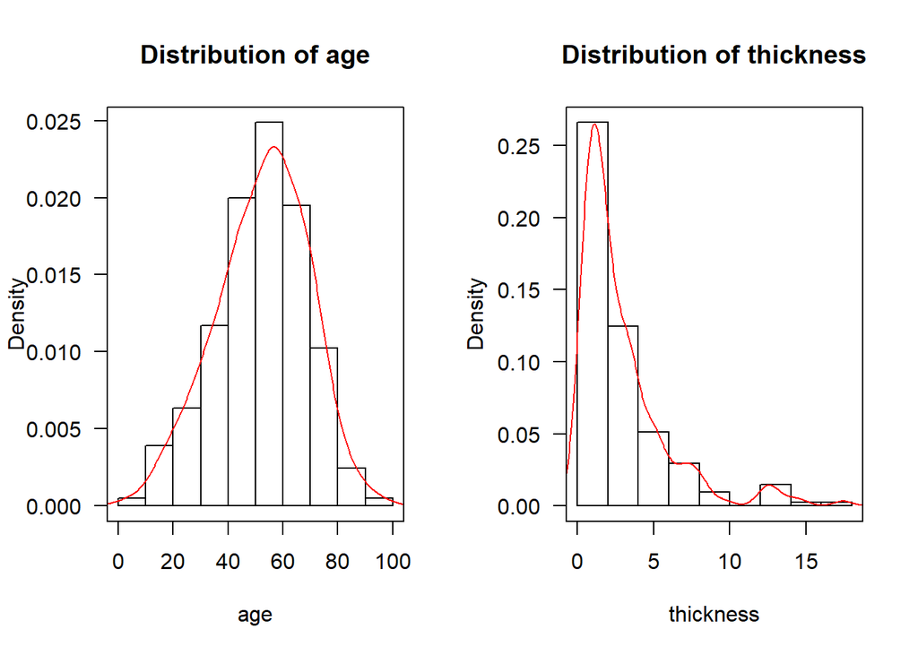

```r
par(mfrow = c(1, 2))
# Boucle sur toutes les variables quantitatives avec courbe de densité

for (var in vars_quanti) {
# 1. Tracer l'histogramme en mode "densité de probabilité" (prob = TRUE)
hist(Melanoma[[var]],
main = paste("Distribution of", var), # Titre dynamique
xlab = var,                           # Nom de la variable sur l'axe X
ylab = "Density",                     # L'axe Y devient la Densité
las  = 1,  # Labels horizontaux
col  = "white",                       # Barres blanches
border = "black",                     # Contours noirs
prob = TRUE)                          # OBLIGATOIRE pour la densité

  # 2. Calculer et superposer la courbe de densité
# na.rm = TRUE est crucial car il peut y avoir des NA dans la colonne 'nodes'

lines(density(Melanoma[[var]], na.rm = TRUE),
col = "red",                         # Courbe en rouge pour le contraste
lwd = 1)                             # Épaisseur de la ligne
# 3. AJOUT DU CADRE AUTOUR DU GRAPHIQUE
box(col = "black", lwd = 1)
}
```

## **Descriptive analysis of categorical variables**

```r
library(gtsummary)

library(dplyr)

data <- as.data.frame(Melanoma)

# CRÉATION D'UN NOUVEAU JEU DE DONNÉES pour le tableau gtsummary
# Le jeu de données original reste strictement intact

data %>%
  mutate(
    sex = factor(sex, levels = c(0, 1), labels = c("Female", "Male")),
    status = factor(status, levels = c(1, 2, 3), labels = c("Died from melanoma", "Alive", "Died from other causes")),
    ulcer = factor(ulcer, levels = c(0, 1), labels = c("Absent", "Present"))
  )%>%
  select(sex, status, ulcer) %>%
  tbl_summary(
    by = status, # Analyse croisée selon la présence/absence d'ulcère
    type = all_categorical() ~ "categorical",
    statistic = all_categorical() ~ "{n} ({p}%)",
    digits    = all_categorical() ~ list(0, 1),
    missing_text = "Missing"
  ) %>%
  bold_labels()
```

| **Characteristic** | **Died from melanoma** N = 57<sup>1</sup> | **Alive** N = 134<sup>1</sup> | **Died from other causes** N = 14<sup>1</sup> |
| --- | --- | --- | --- |
| sex |  |  |  |
| Female | 28 (49.1%) | 91 (67.9%) | 7 (50.0%) |
| Male | 29 (50.9%) | 43 (32.1%) | 7 (50.0%) |
| ulcer |  |  |  |
| Absent | 16 (28.1%) | 92 (68.7%) | 7 (50.0%) |
| Present | 41 (71.9%) | 42 (31.3%) | 7 (50.0%) |

<sup>1</sup> n (%)

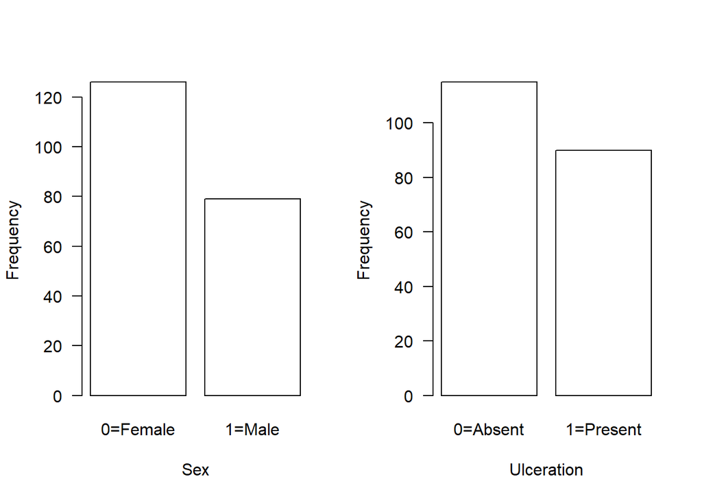

```r
# Configuration de la grille graphique (1 ligne, 2 colonnes)
par(mfrow = c(1, 2))

# ── 1. SEX (Sexe) ──────────────────────────────────────
# Utilisation directe du jeu de données ORIGINAL 'data'
barplot(
  table(data$sex),
  ylab      = "Frequency",
  xlab      = "Sex",
  names.arg = c("0=Female", "1=Male"),
  col       = "white",
  border    = "black",
  las       = 1,
  cex.names = 1.0,
  cex.lab   = 1.0
)

# ── 2. ULCER (Ulcération) ──────────────────────────────
# Utilisation directe du jeu de données ORIGINAL 'data'
barplot(
  table(data$ulcer),
  ylab      = "Frequency",
  xlab      = "Ulceration",
  names.arg = c("0=Absent", "1=Present"),
  col       = "white",
  border    = "black",
  las       = 1,
  cex.names = 1.0,
  cex.lab   = 1.0
)
```

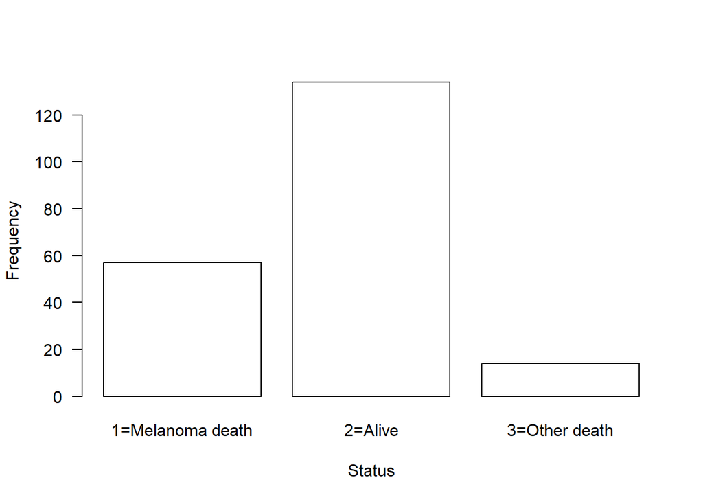

```r
# Rétablir l'affichage à un seul graphique
par(mfrow = c(1, 1))

# ── 3. STATUS (Statut de survie) ───────────────────────
# Utilisation directe du jeu de données ORIGINAL 'data'
barplot(
  table(data$status),
  ylab      = "Frequency",
  xlab      = "Status",
  names.arg = c("1=Melanoma death", "2=Alive", "3=Other death"),
  col       = "white",
  border    = "black",
  las       = 1,
  cex.names = 1.0,
  cex.lab   = 1.0
)
```

## **Missing data**

Prior to data analysis, a rigorous data quality assessment was performed on the dataset. The integrity check confirmed that the dataset contains zero duplicate records. Furthermore, an evaluation of missingness across all clinical variables revealed no missing values.

```r
tab_NA <- data.frame(
  Variables = names(Melanoma),
  n_NA = colSums(is.na(Melanoma)),
  percent_NA = round(colMeans(is.na(Melanoma)) * 100, 2),
  row.names = NULL )

print(tab_NA)
```

```
##   Variables n_NA percent_NA
## 1      time    0          0
## 2    status    0          0
## 3       sex    0          0
## 4       age    0          0
## 5      year    0          0
## 6 thickness    0          0
## 7     ulcer    0          0
```

```r
#Vérifier les doublons
sum(duplicated(Melanoma))
```

```
## [1] 0
```

## **Cumulative Incidence of Melanoma-Specific Death**

Cumulative incidence functions for melanoma-specific death were estimated, treating death from other causes as a competing risk. The presence of ulceration was associated with a markedly higher cumulative incidence of melanoma death compared with non-ulcerated tumors (Gray’s test, p < 0.001), with no significant association for death from other causes (p = 0.69). Similarly, patients with a high tumor thickness (> 1.94 mm) had a significantly higher cumulative incidence of melanoma death than those with a low thickness (≤ 1.94 mm; Gray’s test, p < 0.001), while no significant association was found for death from other causes (p = 0.99). Male sex was also associated with a significantly higher cumulative incidence of melanoma death compared with female sex (Gray’s test, p = 0.016), with no significant association for death from other causes (p = 0.36). These findings confirm the prognostic value of ulceration, tumor thickness, and sex specifically for melanoma-specific mortality, while properly accounting for the competing risk of death from other causes.

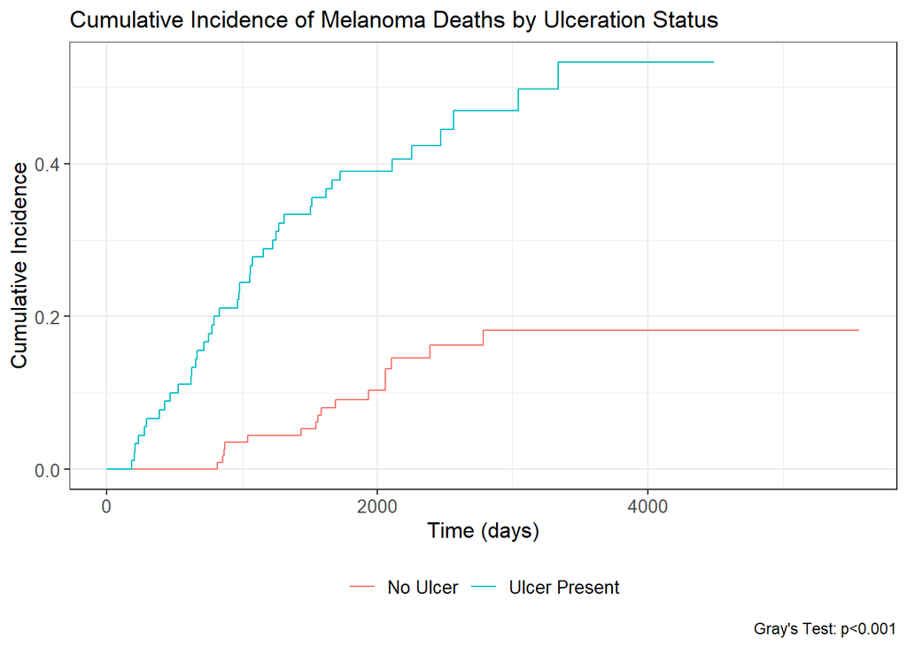

```r
# 2. Préparer les données (on transforme le statut en texte clair)

Melanoma$status_cr <- factor(Melanoma$status,
                             levels = c(2, 1, 3), #l'ordre des niveaux (censures, l'évènement d'intérêt, le risque compétitif)
                             labels = c("censor", "melanoma", "other_cause"))

#la règle d'ordre des niveaux (levels) pour les risques compétitifs en R :

#• 1er niveau (ici 2) : La censure (obligatoirement en premier, car R y cherche les patients vivants).

#2e niveau (ici 1) : L'événement d'intérêt (le décès par mélanome).

#3e niveau (ici 3) : Le risque compétitif (le décès par une autre cause).


library(tidycmprsk)
library(ggsurvfit)
library(ggplot2)

par(mfrow = c(1, 3))

# ---------------------------------------------------------
#Les Courbes d'incidence cumulée  (équivalent de courbe de K-M)
# ---------------------------------------------------------

################## 1.ULCER #######################################

cuminc(Surv(time, status_cr) ~ ulcer, data = Melanoma) %>%
  ggcuminc(outcome = "melanoma") +
  add_pvalue(caption = "Gray's Test: {p.value}") +
  labs(title = "Cumulative Incidence of Melanoma Deaths by Ulceration Status",
       x = "Time (days)",
       y = "Cumulative Incidence") +
  scale_color_discrete(labels = c("0" = "No Ulcer", "1" = "Ulcer Present"))
```

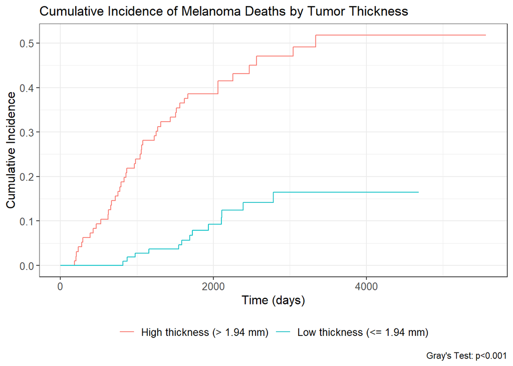

```r
################## 2.THICKNESS ###################################

# Créer temporairement une variable catégorielle basée sur la médiane
Melanoma$thickness_group <- ifelse(Melanoma$thickness <= median(Melanoma$thickness),
                                   "Low thickness (<= 1.94 mm)",
                                   "High thickness (> 1.94 mm)")

cuminc(Surv(time, status_cr) ~ thickness_group, data = Melanoma) %>%
  ggcuminc(outcome = "melanoma") +
  add_pvalue(caption = "Gray's Test: {p.value}") +
  labs(title = "Cumulative Incidence of Melanoma Deaths by Tumor Thickness",
       x = "Time (days)",
       y = "Cumulative Incidence")
```

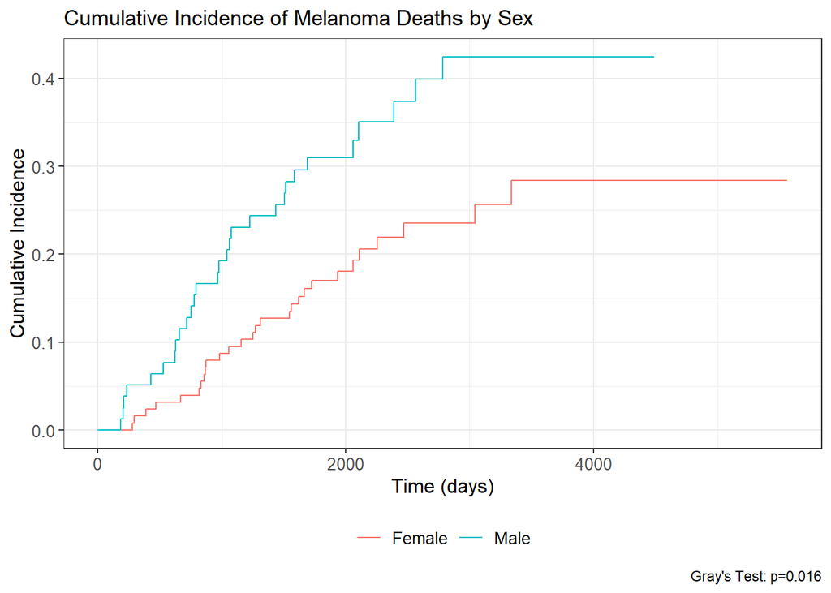

```r
################# 3.SEX #########################################
cuminc(Surv(time, status_cr) ~ sex, data = Melanoma) %>%
  ggcuminc(outcome = "melanoma") +
  add_pvalue(caption = "Gray's Test: {p.value}") + #
  labs(title = "Cumulative Incidence of Melanoma Deaths by Sex",
       x = "Time (days)",
       y = "Cumulative Incidence") +
  scale_color_discrete(labels = c("0" = "Female", "1" = "Male"))
```

```r
#Gray's test :

#######################ulcer#######################################

# Extraire le tableau des tests
tests_ulcer <- test_gray_ulcer$cmprsk$Tests

# Renommer les lignes
rownames(tests_ulcer) <- c("melanoma", "other_cause")

# Créer un data.frame formaté
tests_ulcer_arrondi <- data.frame(
  Outcome = rownames(tests_ulcer),
  Statistic = round(tests_ulcer[, "stat"], 2),
  p_value = ifelse(tests_ulcer[, "pv"] < 0.001, "< 0.001",
                   round(tests_ulcer[, "pv"], 3)),
  df = as.integer(tests_ulcer[, "df"]),
  row.names = NULL
)

# Afficher
print(tests_ulcer_arrondi)
```

```
##       Outcome Statistic p_value df
## 1    melanoma     26.12 < 0.001  1
## 2 other_cause      0.16    0.69  1
```

```r
######################thickness_group##############################

# Extraire le tableau des tests
tests_thickness <- test_gray_thickness_group$cmprsk$Tests

# Renommer les lignes
rownames(tests_thickness) <- c("melanoma", "other_cause")

# Arrondir : 2 décimales pour stat, 3 pour p-value, et df en entier
tests_thickness_arrondi <- data.frame(
  stat = round(tests_thickness[, "stat"], 2),
  p_value = round(tests_thickness[, "pv"], 7),
  df = as.integer(tests_thickness[, "df"])
)

# Afficher
print(tests_thickness_arrondi)
```

```
##              stat   p_value df
## melanoma    28.87 0.0000001  1
## other_cause  0.00 0.9887330  1
```

```r
####################### sex ######################################
# Extraire le tableau des tests
tests_sex <- test_gray_sex$cmprsk$Tests

# Renommer les lignes
rownames(tests_sex) <- c("melanoma", "other_cause")

# Créer un data.frame formaté
tests_sex_arrondi <- data.frame(
  Outcome = rownames(tests_sex),
  Statistic = round(tests_sex[, "stat"], 2),
  p_value = ifelse(tests_sex[, "pv"] < 0.001, "< 0.001",
                   round(tests_sex[, "pv"], 3)),
  df = as.integer(tests_sex[, "df"]),
  row.names = NULL
)

# Afficher
print(tests_sex_arrondi)
```

```
##       Outcome Statistic p_value df
## 1    melanoma      5.81   0.016  1
## 2 other_cause      0.85   0.355  1
```

## **Statistical Modeling and Diagnostics**

To account for the presence of a competing event (death from other causes), a Fine and Gray subdistribution hazard model was fitted for the event of interest (melanoma-specific death). The status variable was recoded as a competing risk outcome with three ordered levels: censoring, melanoma death (event of interest), and death from other causes (competing event). The model included ulceration, tumor thickness, age, and sex as covariates. The regression coefficients from the Fine and Gray model were reported as subdistribution hazard ratios (sHR) with 95% confidence intervals (CIs), allowing interpretation of the effect of each covariate on the cumulative incidence of melanoma-specific death while appropriately accounting for the competing risk of death from other causes.

```r
# Ajustement du modèle

# 1. Charger les packages

library(MASS)
library(tidycmprsk)
library(ggsurvfit) # Pour les graphiques


# 2. Préparer les données (on transforme le statut en texte clair)

Melanoma$status_cr <- factor(Melanoma$status,
                             levels = c(2, 1, 3), #l'ordre des niveaux (censures, l'évènement d'intérêt, le risque compétitif)
                             labels = c("censor", "melanoma", "other_cause"))

#la règle d'ordre des niveaux (levels) pour les risques compétitifs en R :

#1er niveau (ici 2) : La censure (obligatoirement en premier, car R y cherche les patients vivants).

#2e niveau (ici 1) : L'événement d'intérêt (le décès par mélanome).

#3e niveau (ici 3) : Le risque compétitif (le décès par une autre cause).

# ---------------------------------------------------------
# ESTIMER Le modèle de Fine & Gray
# ---------------------------------------------------------
mod_fg <- crr(Surv(time, status_cr) ~ ulcer + thickness + age + sex,
                     data = Melanoma,
                     failcode = "melanoma") #l'événement d'intérêt
```

The proportional subdistribution hazards assumption of the Fine and Gray model was assessed using the Schoenfeld residual test. The global test indicated a violation of the assumption (p = 0.038). At the individual covariate level, significant time-varying effects were observed for ulceration (p = 0.038) and tumor thickness (p = 0.010), as illustrated by the non-horizontal smoothed trends of the scaled Schoenfeld residuals over time. No significant violations were found for age (p = 0.459) or sex (p = 0.215). These results suggest that the effects of ulceration and tumor thickness on the cumulative incidence of melanoma-specific death may not be constant over time, indicating a need for cautious interpretation of the corresponding subdistribution hazard ratios. However, when time-dependent interaction terms were introduced into the model, none were statistically significant (ulcer × log(time): p = 0.3; thickness × log(time): p = 0.8). Given these findings, the model without interactions was retained for the main analysis, and the subdistribution hazard ratios should be interpreted with caution in light of a potential time-varying effect.

```r
# Vérifier les conditions de validité

# Appliquer le test de proportionnalité sur la structure cmprsk de mon modèle

library(MASS)
library(survival)

# 1. Préparer les données en risques compétitifs (Rappel)
Melanoma$status_cr <- factor(Melanoma$status,
                             levels = c(2, 1, 3),
                             labels = c("censor", "melanoma", "other_cause"))

# 2. Transformer le jeu de données pour le modèle de Fine and Gray
melanoma_fg_data <- finegray(Surv(time, status_cr) ~ ulcer + thickness + age + sex,
                             data = Melanoma,
                             etype = "melanoma")

# 3. Estimer le modèle avec coxph (nécessaire pour cox.zph)
mod_coxph <- coxph(Surv(fgstart, fgstop, fgstatus) ~ ulcer + thickness + age + sex,
                   data = melanoma_fg_data,
                   weight = fgwt)

# 4. Test de proportionnalité
test_validite <- cox.zph(mod_coxph)
print(test_validite)
```

```
##            chisq df     p
## ulcer      4.288  1 0.038
## thickness  6.559  1 0.010
## age        0.549  1 0.459
## sex        1.535  1 0.215
## GLOBAL    10.142  4 0.038
```

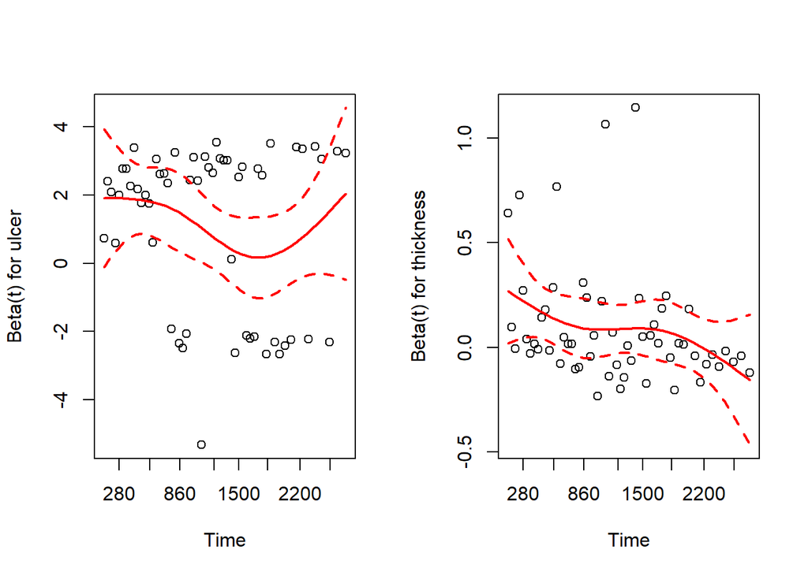

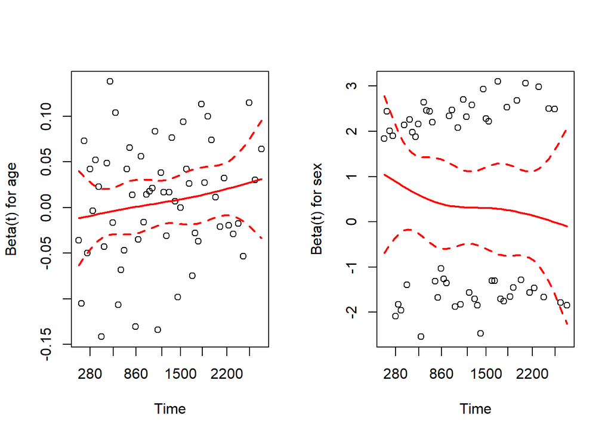

```r
library(survminer)


# Générer les graphiques de résidus pour chaque variable

par(mfrow = c(1, 2))

plot(cox.zph(mod_coxph), col="red", lwd=2)
```

# **Results**

The presence of ulceration was significantly associated with an increased subdistribution hazard of melanoma death (sHR = 3.09; 95% CI: 1.71–5.60; p < 0.001).

Similarly, higher tumor thickness was associated with a significantly increased hazard (sHR = 1.09 ; 95% CI: 1.01–1.18; p = 0.019).

In contrast, age (sHR = 1.01; 95% CI: 0.99–1.02; p = 0.5) and male sex (sHR = 1.50; 95% CI: 0.87–2.57; p = 0.14) were not significantly associated with melanoma-specific death.

```r
# Résultats (Subdistribution HR)

library(gtsummary)

tbl_regression(mod_fg, exponentiate = TRUE)
```

| **Characteristic** | **HR** | **95% CI** | **p-value** |
| --- | --- | --- | --- |
| ulcer | 3.09 | 1.71, 5.60 | <0.001 |
| thickness | 1.09 | 1.01, 1.18 | 0.019 |
| age | 1.01 | 0.99, 1.02 | 0.5 |
| sex | 1.50 | 0.87, 2.57 | 0.14 |

Abbreviations: CI = Confidence Interval, HR = Hazard Ratio

# **Conclusion**

In this cohort of patients with malignant melanoma, ulceration and tumor thickness were independent prognostic factors for melanoma-specific death, even after accounting for the competing risk of death from other causes.

These findings underscore the importance of these two clinical parameters in the initial risk stratification and management of melanoma. Further studies with larger sample sizes and longer follow-up may be needed to clarify the prognostic role of sex and age in this setting.